# MSc_CW1_13175438_S_Khan

# 4. Linear Regression

This question involves the use of simple linear regression on the Auto data set.

**(a) Use the lm() function to perform a simple linear regression with mpg as the response and horsepower as the predictor. Use the summary() function to print the results. Comment on the output.**

```r
lm.fit <- lm(formula=mpg~horsepower, data=Auto)
summary(lm.fit)
```

```
##
## Call:
## lm(formula = mpg ~ horsepower, data = Auto)
##
## Residuals:
##      Min       1Q   Median       3Q      Max
## -13.5710  -3.2592  -0.3435   2.7630  16.9240
##
## Coefficients:
##              Estimate Std. Error t value Pr(>|t|)
## (Intercept) 39.935861   0.717499   55.66   <2e-16 ***
## horsepower  -0.157845   0.006446  -24.49   <2e-16 ***
## ---
## Signif. codes:  0 '***' 0.001 '**' 0.01 '*' 0.05 '.' 0.1 ' ' 1
##
## Residual standard error: 4.906 on 390 degrees of freedom
## Multiple R-squared:  0.6059, Adjusted R-squared:  0.6049
## F-statistic: 599.7 on 1 and 390 DF,  p-value: < 2.2e-16
```

**i. Is there a relationship between the predictor and the response?**

The function shows a high (absolute) t value with a very small p value. This suggests there is indeed a relationship between the two, and the below graphic confirms this.

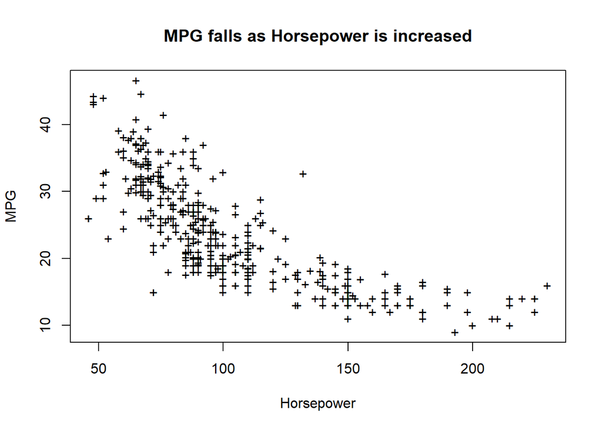

```r
plot(Auto$horsepower, Auto$mpg, xlab='Horsepower',ylab='MPG',main='MPG falls as Horsepower is increased',pch='+')
```

**ii. How strong is the relationship between the predictor and the response?**

We can look at the adjusted R-squared value to illustrate how strong the relationship is. In this case, 60.49% of the variance has been explained by using horsepower as a predictor in a simple linear model.

**iii. Is the relationship between the predictor and the response positive or negative?**

The model gives an estimated coefficient value of -0.1578447, which suggests a negative relationship between horsepower and mpg. This is in line with our earlier observation from the plots.

**iv. What is the predicted mpg associated with a horsepower of 89? What are the associated 99% confidence and prediction intervals?**

```r
new_horsepower <- data.frame(horsepower=89)
lm.predict.conf99 <- predict(lm.fit, newdata=new_horsepower, interval='confidence',level=0.99)
lm.predict.pred99 <- predict(lm.fit, newdata=new_horsepower, interval='prediction',level=0.99)
```

89 horsepower is associated with a predicted 25.89 mpg.

The associated 99% *confidence interval* is between 25.2 and 26.58 mpg.

The associated 99% *prediction interval* is between 13.17 and 38.61 mpg. We expect the prediction intervals to be wider than the confidence intervals.

**(b) Plot the response and the predictor. Use the abline() function to display the least squares regression line.**

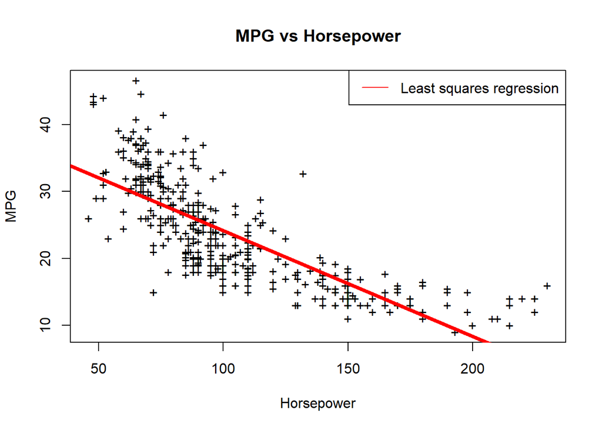

```r
plot(Auto$horsepower,Auto$mpg,xlab='Horsepower', ylab='MPG', main='MPG vs Horsepower',pch='+')
abline(lm.fit,col='red',lwd=4)
legend("topright",c('Least squares regression'),lty=1,col='red')
```

**(c) Plot the 99% confidence interval and prediction interval in the same plot as (b) using different colours and legends.**

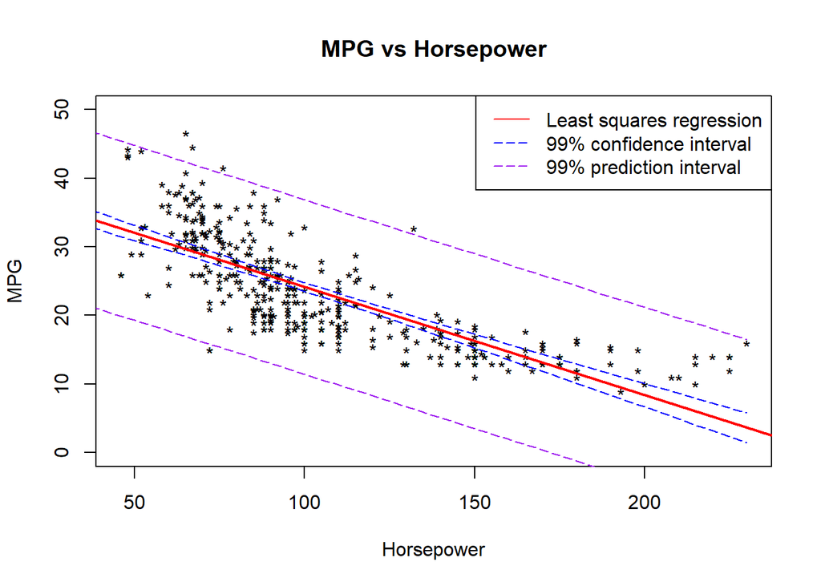

```r
plot(Auto$horsepower,Auto$mpg,xlab='Horsepower', ylab='MPG', main='MPG vs Horsepower',pch='*',ylim=c(0,50))
abline(lm.fit,col='red',lwd=2)

newHorsepower <- data.frame(horsepower=seq(30,230,by=5))

pred_conf <- predict(lm.fit,newdata=newHorsepower,interval='confidence',level=0.99)
pred_pred <- predict(lm.fit,newdata=newHorsepower,interval='prediction',level=0.99)

lines(newHorsepower$horsepower, pred_conf[,'upr'],lty=5,lwd=1,col='blue')
lines(newHorsepower$horsepower, pred_conf[,'lwr'],lty=5,lwd=1,col='blue')
lines(newHorsepower$horsepower, pred_pred[,'upr'],lty=5,lwd=1,col='purple')
lines(newHorsepower$horsepower, pred_pred[,'lwr'],lty=5,lwd=1,col='purple')

legend("topright",c('Least squares regression','99% confidence interval','99% prediction interval'),
       lty=c(1,5,5),
       col=c('red','blue','purple'))
```

# 5. Logistic Regression

**(a) Load the training and testing datasets from corresponding files, and display the statistics about different features in the training dataset.**

```r
trainingset <- read.csv('Training_set for Q5.txt')
testset <- read.csv('Testing_set for Q5.txt')
```

```r
str(trainingset)
```

```
## 'data.frame':    2000 obs. of  6 variables:
##  $ Temperature  : num  23.2 23.1 23.1 23.1 23.1 ...
##  $ Humidity     : num  27.3 27.3 27.2 27.2 27.2 ...
##  $ Light        : num  426 430 426 426 426 ...
##  $ CO2          : num  721 714 714 708 704 ...
##  $ HumidityRatio: num  0.00479 0.00478 0.00478 0.00477 0.00476 ...
##  $ Occupancy    : int  1 1 1 1 1 1 1 1 1 1 ...
```

**(b) Build a logistic regression model by only using the Temperature feature to predict the room occupancy. Display the confusion matrix and the predictive accuracy obtained on the testing dataset.**

```r
trainingset$Occupancy <- factor(trainingset$Occupancy)

glm.fit.temp <- glm(formula=Occupancy~Temperature,data=trainingset,family=binomial)
summary(glm.fit.temp)
```

```
##
## Call:
## glm(formula = Occupancy ~ Temperature, family = binomial, data = trainingset)
##
## Deviance Residuals:
##     Min       1Q   Median       3Q      Max
## -2.2180  -0.4862  -0.3368   0.6739   2.5871
##
## Coefficients:
##             Estimate Std. Error z value Pr(>|z|)
## (Intercept) -54.4413     2.4166  -22.53   <2e-16 ***
## Temperature   2.4701     0.1107   22.32   <2e-16 ***
## ---
## Signif. codes:  0 '***' 0.001 '**' 0.01 '*' 0.05 '.' 0.1 ' ' 1
##
## (Dispersion parameter for binomial family taken to be 1)
##
##     Null deviance: 2362.3  on 1999  degrees of freedom
## Residual deviance: 1548.5  on 1998  degrees of freedom
## AIC: 1552.5
##
## Number of Fisher Scoring iterations: 5
```

```r
glm.probs.temp <- predict(glm.fit.temp, newdata=testset, type='response')
summary(glm.probs.temp)
```

```
##    Min. 1st Qu.  Median    Mean 3rd Qu.    Max.
## 0.01669 0.03094 0.14305 0.33731 0.54063 0.99699
```

```r
dim(testset)
```

```
## [1] 300   6
```

```r
glm.pred.temp <- rep(0,nrow(testset))
glm.pred.temp[glm.probs.temp>0.5] <- 1

table(truth=testset$Occupancy, prediction=glm.pred.temp)
```

```
##      prediction
## truth   0   1
##     0 182  58
##     1  39  21
```

The TEMPERATURE model obtained an accuracy rate of 0.68 (and therefore an error rate of 0.32).

**(c) Build a logistic regression model by only using the Humidity feature to predict the room occupancy. Display the confusion matrix and the predictive accuracy obtained on the testing dataset.**

```r
glm.fit.hum <- glm(Occupancy~Humidity, data=trainingset, family=binomial)
summary(glm.fit.hum)
```

```
##
## Call:
## glm(formula = Occupancy ~ Humidity, family = binomial, data = trainingset)
##
## Deviance Residuals:
##     Min       1Q   Median       3Q      Max
## -1.4511  -0.8361  -0.2682   0.8937   2.3203
##
## Coefficients:
##              Estimate Std. Error z value Pr(>|z|)
## (Intercept) -16.56899    0.94141  -17.60   <2e-16 ***
## Humidity      0.62293    0.03659   17.02   <2e-16 ***
## ---
## Signif. codes:  0 '***' 0.001 '**' 0.01 '*' 0.05 '.' 0.1 ' ' 1
##
## (Dispersion parameter for binomial family taken to be 1)
##
##     Null deviance: 2362.3  on 1999  degrees of freedom
## Residual deviance: 1845.8  on 1998  degrees of freedom
## AIC: 1849.8
##
## Number of Fisher Scoring iterations: 5
```

```r
glm.probs.hum <- predict(glm.fit.hum, newdata=testset, type='response')
summary(glm.probs.hum)
```

```
##    Min. 1st Qu.  Median    Mean 3rd Qu.    Max.
##  0.0498  0.2055  0.4575  0.4960  0.7966  0.9971
```

```r
glm.pred.hum <- rep(0,nrow(testset))
glm.pred.hum[glm.probs.hum>0.5] <- 1

table(truth=testset$Occupancy, prediction=glm.pred.hum)
```

```
##      prediction
## truth   0   1
##     0 133 107
##     1  22  38
```

The HUMIDITY model obtained an accuracy rate of 0.57 (and therefore an error rate of 0.43).

**(d) Build a logistic regression model by using all features to predict the room occupancy. Display the confusion matrix and the predictive accuracy obtained on the testing dataset.**

```r
glm.fit.all <- glm(formula=Occupancy~., data=trainingset, family=binomial)
summary(glm.fit.all)
```

```
##
## Call:
## glm(formula = Occupancy ~ ., family = binomial, data = trainingset)
##
## Deviance Residuals:
##     Min       1Q   Median       3Q      Max
## -2.9467  -0.1274  -0.1082   0.2486   2.0429
##
## Coefficients:
##                 Estimate Std. Error z value Pr(>|z|)
## (Intercept)    9.089e+00  4.658e+01   0.195    0.845
## Temperature   -1.102e+00  2.185e+00  -0.504    0.614
## Humidity       8.278e-01  1.351e+00   0.613    0.540
## Light          1.415e-02  1.100e-03  12.864  < 2e-16 ***
## CO2            4.800e-03  1.034e-03   4.642 3.45e-06 ***
## HumidityRatio -3.495e+03  8.434e+03  -0.414    0.679
## ---
## Signif. codes:  0 '***' 0.001 '**' 0.01 '*' 0.05 '.' 0.1 ' ' 1
##
## (Dispersion parameter for binomial family taken to be 1)
##
##     Null deviance: 2362.3  on 1999  degrees of freedom
## Residual deviance:  487.4  on 1994  degrees of freedom
## AIC: 499.4
##
## Number of Fisher Scoring iterations: 7
```

```r
glm.probs.all <- predict(glm.fit.all, newdata=testset, type='response')
summary(glm.probs.all)
```

```
##     Min.  1st Qu.   Median     Mean  3rd Qu.     Max.
## 0.000283 0.022467 0.048911 0.334650 0.818187 0.997551
```

```r
glm.pred.all <- rep(0,nrow(testset))
glm.pred.all[glm.probs.all>0.5] <- 1

table(truth=testset$Occupancy, prediction=glm.pred.all)
```

```
##      prediction
## truth   0   1
##     0 184  56
##     1  13  47
```

The model using ALL features obtained an accuracy rate of 0.77 (and therefore an error rate of 0.23).

**(e) Compare the predictive performance of three different models by drawing ROC curves and calculating the AUROC values. Discuss the comparison results.**

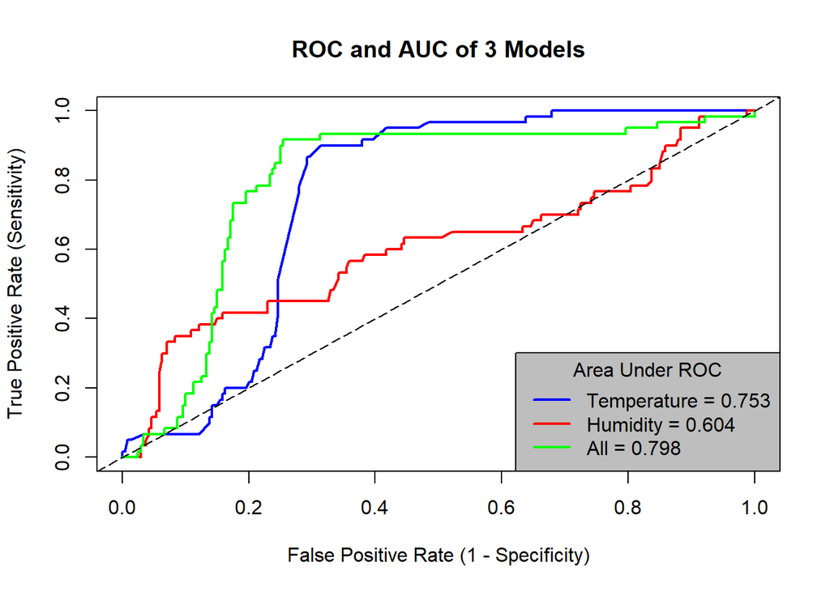

```r
temp.trained.model <- prediction(glm.probs.temp,testset$Occupancy)
auroc_temp.trained.model <- performance(temp.trained.model, measure='auc')
auroc_temp <- auroc_temp.trained.model@y.values[[1]]

hum.trained.model <- prediction(glm.probs.hum, testset$Occupancy)
auroc_hum.trained.model <- performance(hum.trained.model, measure='auc')
auroc_hum <- auroc_hum.trained.model@y.values[[1]]

all.trained.model <- prediction(glm.probs.all, testset$Occupancy)
auroc_all.trained.model <- performance(all.trained.model, measure='auc')
auroc_all <- auroc_all.trained.model@y.values[[1]]


pr_temp.trained.model <- performance(temp.trained.model, measure='tpr', x.measure='fpr')
pr_hum.trained.model <- performance(hum.trained.model, measure='tpr', x.measure='fpr')
pr_all.trained.model <- performance(all.trained.model, measure='tpr', x.measure='fpr')

plot(pr_temp.trained.model, col='blue', xlab='False Positive Rate (1 - Specificity)',
     ylab='True Positive Rate (Sensitivity)',lwd=2, main="ROC and AUC of 3 Models")
plot(pr_hum.trained.model, add=T, col='red', lwd=2)
plot(pr_all.trained.model, add=T, col='green',lwd=2)
abline(0,1,lty=5)
legend(title='Area Under ROC','bottomright',
       c(text=sprintf('Temperature = %s', round(auroc_temp, digits=3)),
         text=sprintf('Humidity = %s', round(auroc_hum, digits=3)),
         text=sprintf('All = %s', round(auroc_all, digits=3))),
       lty=1,col=c('blue','red','green'),
       lwd=c(2,2,2),
       bg='grey')
```

# 6. Resampling Methods

We are trying to learn regression parameters for a dataset which we know was generated from a polynomial of a certain degree, but we do not know what this degree is.

**(a) Which of these two models is likely to fit the test data better? Justify your answer.**

Our choice of statistical learning method, based on minimising test error, boils down to a trade off between bias and variance. Bias refers to the error that is introduced by approximating a somewhat complex real life problem using a simpler model. Variance refers to the amount our function would change as a result of using different training data. Our goal is to minimise both the squared bias and the variance.

Typically, when it comes to a dataset generated from some polynomial degree, an increase in flexibility will improve our model performance (if measured by a lower mean squared error), although this too only up to a point before the additional model complexity becomes resource inefficient with diminishing returns in performance.

We can use cross validation techniques to help determine the most suitable methods for our purpose.

If we assume a cubic relationship, we can test this on an example dataset using polynomial models with 2 and 4 degrees.

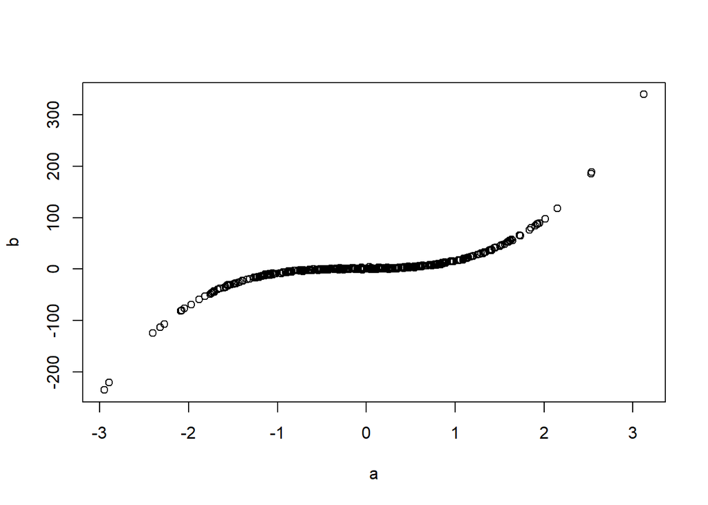

```r
set.seed(420)
a <- rnorm(400)
b <- 1 + 2*a + 3*a^2 + 10*a^3 + rnorm(400)
plot(a,b)
```

Model A: polynomial of degree 2

```r
glm.fit2 <- glm(b~poly(a,2))
summary(glm.fit2)
```

```
##
## Call:
## glm(formula = b ~ poly(a, 2))
##
## Deviance Residuals:
##      Min        1Q    Median        3Q       Max
## -169.589   -12.172    -0.861    12.557   221.762
##
## Coefficients:
##             Estimate Std. Error t value Pr(>|t|)
## (Intercept)    3.846      1.111   3.462 0.000595 ***
## poly(a, 2)1  587.420     22.222  26.435  < 2e-16 ***
## poly(a, 2)2   66.214     22.222   2.980 0.003062 **
## ---
## Signif. codes:  0 '***' 0.001 '**' 0.01 '*' 0.05 '.' 0.1 ' ' 1
##
## (Dispersion parameter for gaussian family taken to be 493.7967)
##
##     Null deviance: 545484  on 399  degrees of freedom
## Residual deviance: 196037  on 397  degrees of freedom
## AIC: 3621
##
## Number of Fisher Scoring iterations: 2
```

Model B: polynomial of degree 4

```r
glm.fit4 <- glm(b~poly(a,4))
summary(glm.fit4)
```

```
##
## Call:
## glm(formula = b ~ poly(a, 4))
##
## Deviance Residuals:
##      Min        1Q    Median        3Q       Max
## -2.62959  -0.68072   0.07721   0.59093   3.01196
##
## Coefficients:
##              Estimate Std. Error t value Pr(>|t|)
## (Intercept)   3.84627    0.04716  81.553   <2e-16 ***
## poly(a, 4)1 587.42008    0.94326 622.755   <2e-16 ***
## poly(a, 4)2  66.21420    0.94326  70.197   <2e-16 ***
## poly(a, 4)3 442.36371    0.94326 468.973   <2e-16 ***
## poly(a, 4)4  -0.42831    0.94326  -0.454     0.65
## ---
## Signif. codes:  0 '***' 0.001 '**' 0.01 '*' 0.05 '.' 0.1 ' ' 1
##
## (Dispersion parameter for gaussian family taken to be 0.8897394)
##
##     Null deviance: 545483.95  on 399  degrees of freedom
## Residual deviance:    351.45  on 395  degrees of freedom
## AIC: 1095.4
##
## Number of Fisher Scoring iterations: 2
```

The residual deviance is far lower using model B (polynomial degree of 4). Also a lower Akaike Information Criterion (AIC), i.e. lower out of sample prediction error, thus a better quality model.

**(b) Create a scatterplot of X against Y.**

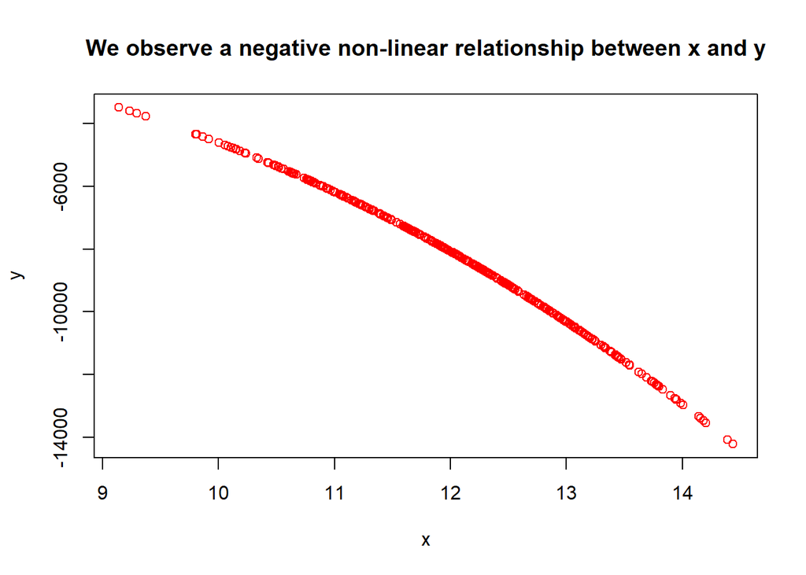

```r
set.seed(235)
x <- 12 + rnorm(400)
y <- 1 - x + 4*x^2 - 5*x^3 + rnorm(400)
plot(x,y, col='red', main='We observe a negative non-linear relationship between x and y')
```

**(c) Set the seed to be 34, and then compute the LOOCV and 10-fold CV errors for the two models.**

```r
library(boot)
df <- data.frame(x,y)
set.seed(34)
```

```r
model_poly2 <- glm(y~poly(x,2), data=df)
cv.error2 <- cv.glm(df, model_poly2)
k.cv.error2 <- cv.glm(df, model_poly2, K=10)
```

Model (i)
$$Y = \beta_{0} + \beta_{1}X + \beta_{2}X^{2} +\epsilon$$

The LOOCV output for model (i) is 100.257 and the 10-fold CV output is 105.135.

```r
model_poly4 <- glm(y~poly(x,4), data=df)
cv.error4 <- cv.glm(df,model_poly4)
k.cv.error4 <- cv.glm(df, model_poly4, K=10)
```

Model (ii)
$$Y = \beta_{0} + \beta_{1}X + \beta_{2}X^{2} + \beta_{3}X^{3} + \beta_{4}X^{4} +\epsilon$$

The LOOCV output for model (ii) is 1.018 and the 10-fold CV output is 1.022.

**(d) Repeat (c) using random seed 68, and report your results. Are your results the same as what you got in (c)? Why?**

```r
set.seed(68)
```

```r
model_poly2 <- glm(y~poly(x,2), data=df)
cv.error2 <- cv.glm(df, model_poly2)
k.cv.error2 <- cv.glm(df, model_poly2, K=10)
```

The LOOCV output for model (i) is 100.257 and the 10-fold CV output is 97.151.

```r
model_poly4 <- glm(y~poly(x,4), data=df)
cv.error4 <- cv.glm(df, model_poly4)
k.cv.error4 <- cv.glm(df, model_poly4, K=10)
```

The LOOCV output for model (ii) is 1.018 and the 10-fold CV output is 1.019.

- LOOCV outputs are the same for both seeds, however K-fold CVs have changed. In K-fold cross validation, a part of the dataset is randomly selected to be the training set and the remainder is the test set. By setting different seeds, different parts (or folds) of the data are selected as training and testing sets. Leave One Out CV is not affected in this way since each fold is deterministic, i.e. since only one sample is split away at a time, there is no randomness in the training/testing set splits.

**(e) Which of the models in (c) had the smallest LOOCV and 10-fold CV error? Is this what you expected? Explain your answer.**

The quartic model (with polynomial degree of 4) had the smallest LOOCV and K-fold errors. The data was generated from a cubic function, and an improvement in model performance is to be expected with increased levels of flexibility.

**(f) Comment on the coefficient estimates and the statistical significance of the coefficient estimates that results from fitting the preferred model in (a).**

```r
summary(glm.fit4)
```

```
##
## Call:
## glm(formula = b ~ poly(a, 4))
##
## Deviance Residuals:
##      Min        1Q    Median        3Q       Max
## -2.62959  -0.68072   0.07721   0.59093   3.01196
##
## Coefficients:
##              Estimate Std. Error t value Pr(>|t|)
## (Intercept)   3.84627    0.04716  81.553   <2e-16 ***
## poly(a, 4)1 587.42008    0.94326 622.755   <2e-16 ***
## poly(a, 4)2  66.21420    0.94326  70.197   <2e-16 ***
## poly(a, 4)3 442.36371    0.94326 468.973   <2e-16 ***
## poly(a, 4)4  -0.42831    0.94326  -0.454     0.65
## ---
## Signif. codes:  0 '***' 0.001 '**' 0.01 '*' 0.05 '.' 0.1 ' ' 1
##
## (Dispersion parameter for gaussian family taken to be 0.8897394)
##
##     Null deviance: 545483.95  on 399  degrees of freedom
## Residual deviance:    351.45  on 395  degrees of freedom
## AIC: 1095.4
##
## Number of Fisher Scoring iterations: 2
```

The p-values for the first 3 degree terms are very low (with high t values), suggesting they are each statistically significant. However, the 4th degree appears not to be significant. This makes sense because the actual model is cubic.

**(g) Fit a cubic model and compute its LOOCV error, 10-fold CV error under seed 34, and comment on the coefficient estimates and the statistical significance of the coefficient estimates. Compare the LOOCV and 10-fold CV error with the preferred model in (a).**

```r
set.seed(34)
model_poly3 <- glm(y~poly(x,3),data=df)
cv.error3 <- cv.glm(df,model_poly3)
k.cv.error3 <- cv.glm(df,model_poly3,K=10)

summary(model_poly3)
```

```
##
## Call:
## glm(formula = y ~ poly(x, 3), data = df)
##
## Deviance Residuals:
##     Min       1Q   Median       3Q      Max
## -2.9184  -0.5950   0.0207   0.6436   3.3436
##
## Coefficients:
##               Estimate Std. Error   t value Pr(>|t|)
## (Intercept) -8.406e+03  5.002e-02 -168056.7   <2e-16 ***
## poly(x, 3)1 -4.207e+04  1.000e+00  -42050.4   <2e-16 ***
## poly(x, 3)2 -4.659e+03  1.000e+00   -4657.2   <2e-16 ***
## poly(x, 3)3 -1.914e+02  1.000e+00    -191.3   <2e-16 ***
## ---
## Signif. codes:  0 '***' 0.001 '**' 0.01 '*' 0.05 '.' 0.1 ' ' 1
##
## (Dispersion parameter for gaussian family taken to be 1.0008)
##
##     Null deviance: 1.7914e+09  on 399  degrees of freedom
## Residual deviance: 3.9632e+02  on 396  degrees of freedom
## AIC: 1141.5
##
## Number of Fisher Scoring iterations: 2
```

The LOOCV output for this model (polynomial degree of 3) is 1.011 and the 10-fold CV output is 1.011.

Now the LOOCV and K-Fold CV error outputs are more in line with each other. Also, all of the p-values in the cubic model are very small, i.e. they are all statistically significant. This makes sense since the actual model is cubic.